# W3school

The `<pre>` tag in HTML stands for "preformatted text." It is used to define preformatted text, meaning that the text within the `<pre>` element is displayed in a fixed-width font, and the text preserves both spaces and line breaks. This tag is commonly used for displaying code snippets, poetry, or any text where the formatting and spacing are important. When the `<pre>` tag is used, the text is displayed exactly as it is written in the HTML code, including any spaces, tabs, and line breaks.

```
<pre>

  My Bonnie lies over the ocean.

  My Bonnie lies over the sea.

  My Bonnie lies over the ocean.

  Oh, bring back my Bonnie to me.
</pre>
```

Defines pre-formatted text

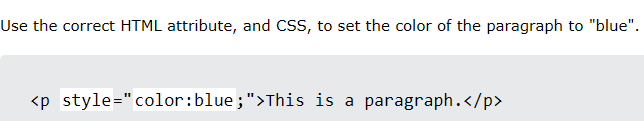

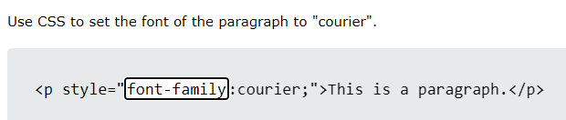

[video not shown]

- The HTML global attribute, "contenteditable" is used to: The HTML global attribute, contenteditable, is used to specify whether the content of an element is editable by the user.
- The HTML `<meter>` element is used to display a scalar measurement within a range. It represents a gauge or measurement within a known range, typically visualized as a horizontal bar or vertical bar. The value is displayed within this range using attributes like `min`, `max`, `value`, and `high`/`low`.
- The `<aside>` element in HTML is used to mark content that is related to the main content of the webpage but can be considered somewhat separate from it. It typically contains content that is tangentially related, such as sidebars, pull-quotes, or additional information like related links, author information, advertisements, etc. The content within the `<aside>` element should be related to the main content but not crucial to understanding it.
- The doctype declaration is not case sensitive. All cases are acceptable -

HTML5

HTML 4.01

XHTML 1.0

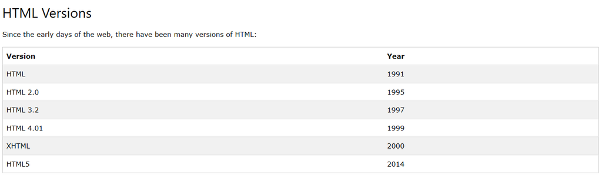

- The link's destination is specified in the href attribute.
- The source file (src), alternative text (alt), and size (width and height) are provided as attributes -

[figure not shown]